# Projekt Metody Statystyczne - Dokumentacja

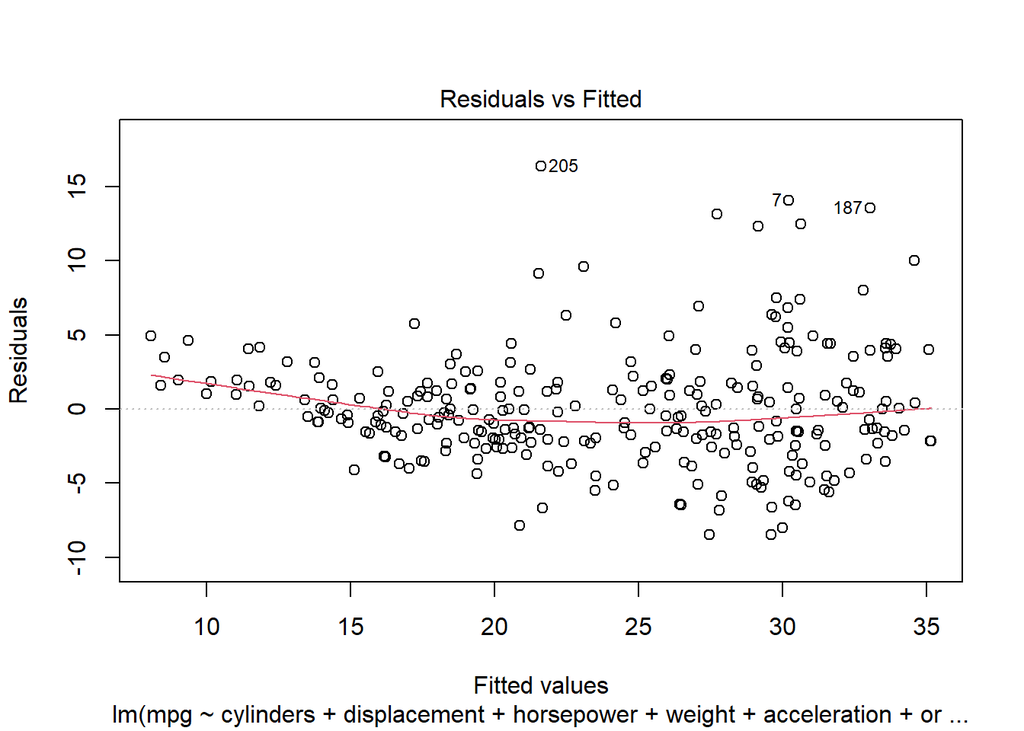

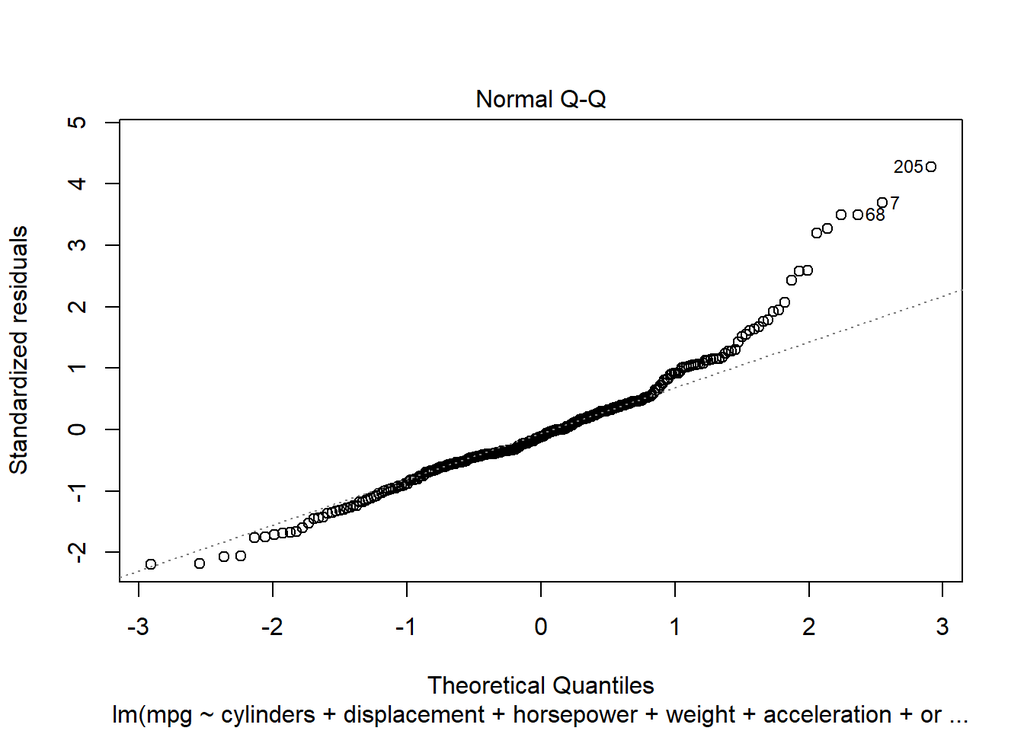

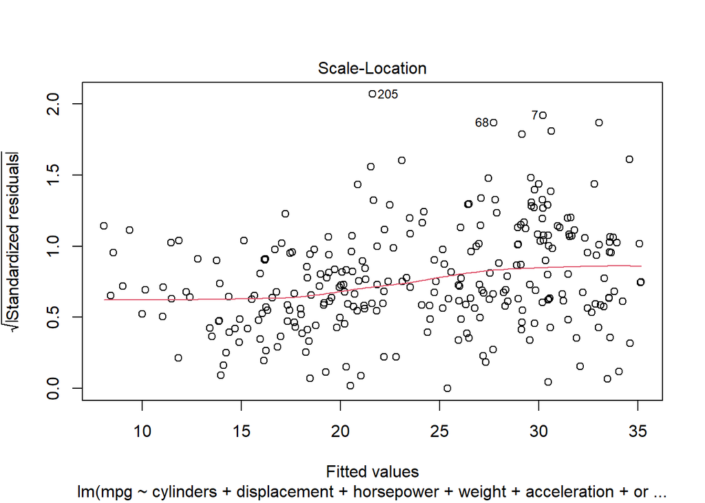

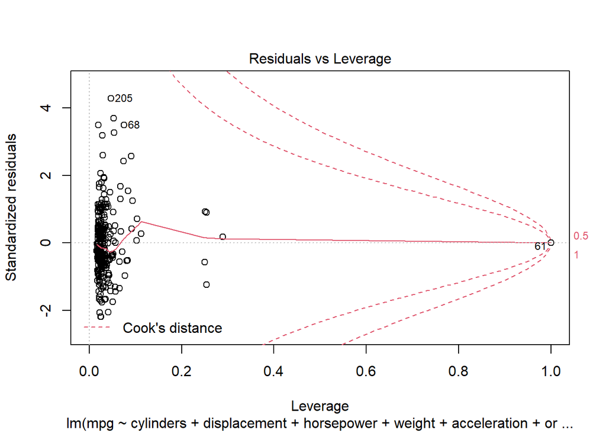

```r
plot(regresja)
```

Displacement i Acceleration są nieistotne Ponówny więc regresję

```r
regresja2<- lm(formula = mpg ~ cylinders + horsepower + weight, data = trainData)
summary(regresja2)
```

```
##
## Call:
## lm(formula = mpg ~ cylinders + horsepower + weight, data = trainData)
##
## Residuals:
##    Min     1Q Median     3Q    Max
## -9.989 -2.535 -0.500  1.975 15.851
##
## Coefficients:
##               Estimate Std. Error t value Pr(>|t|)
## (Intercept) 38.7385766  2.6930243  14.385  < 2e-16 ***
## cylinders4   7.1210435  2.0872332   3.412 0.000744 ***
## cylinders5   9.2094741  4.6918597   1.963 0.050685 .
## cylinders6   3.8441012  2.1944651   1.752 0.080952 .
## cylinders8   6.5123131  2.4053347   2.707 0.007211 **
## horsepower  -0.0611112  0.0156619  -3.902 0.000120 ***
## weight      -0.0050545  0.0007904  -6.395 7.02e-10 ***
## ---
## Signif. codes:  0 '***' 0.001 '**' 0.01 '*' 0.05 '.' 0.1 ' ' 1
##
## Residual standard error: 4.078 on 271 degrees of freedom
## Multiple R-squared:  0.7313, Adjusted R-squared:  0.7254
## F-statistic: 122.9 on 6 and 271 DF,  p-value: < 2.2e-16
```

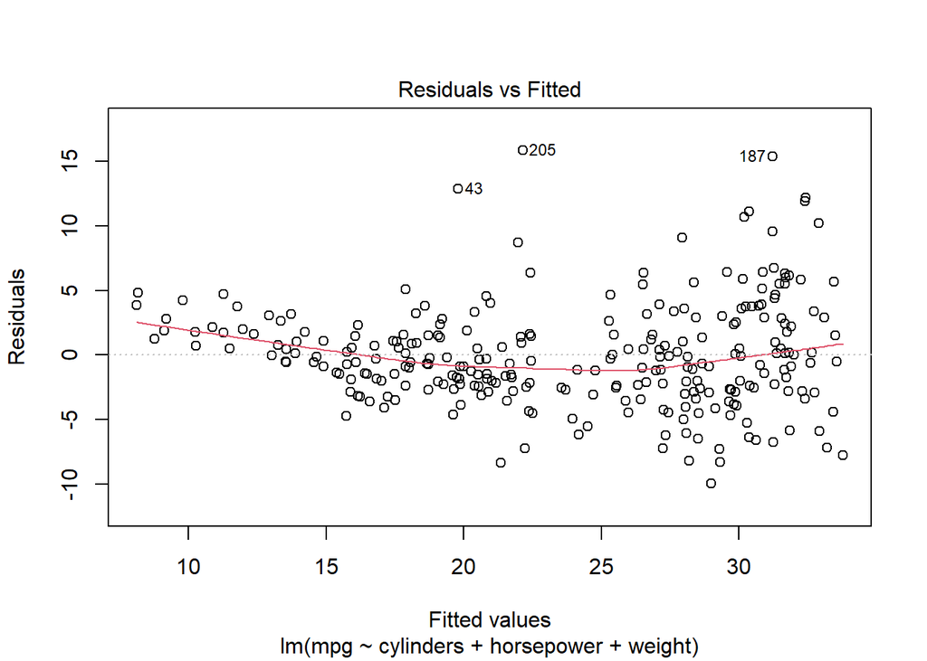

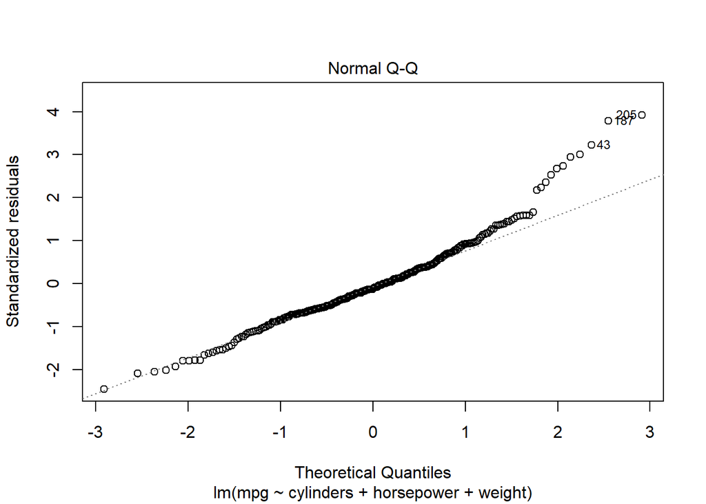

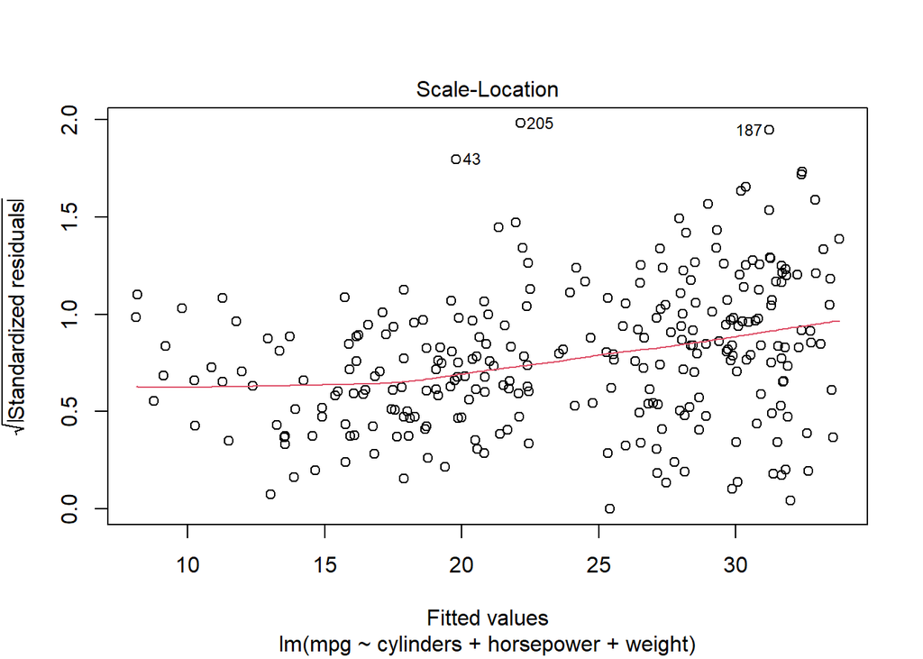

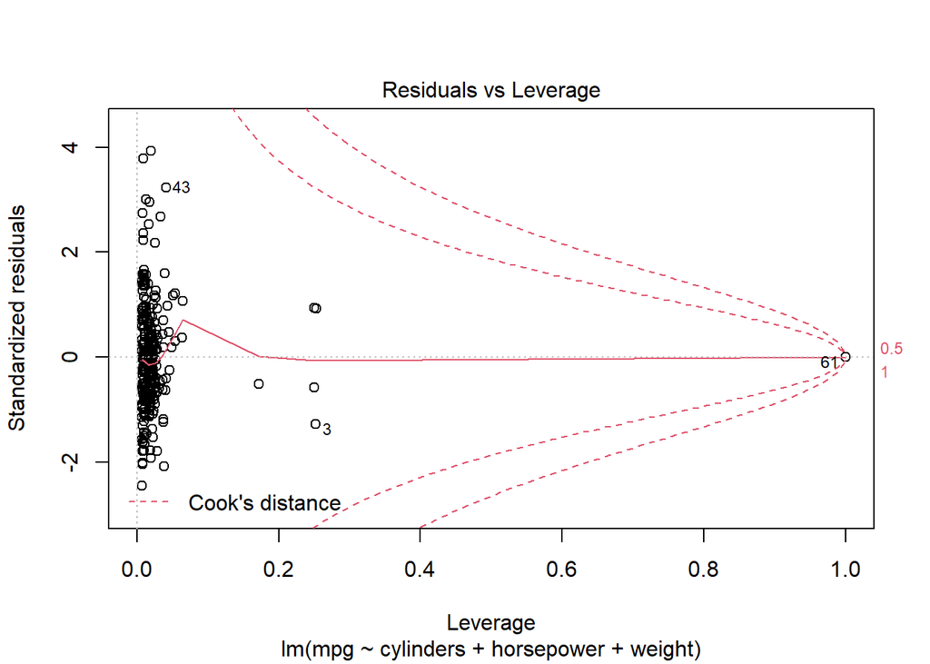

```r
plot(regresja2)
```

Cylinder6 jest statystycznie nieistotne, ale należy zostawić tą zmienną z powodu na inne cylindry.

Tworzymy ramkę danych dla zobaczenia wartości

```r
predykcja <- predict(regresja2, newdata = testData)
```

Różnica procentowa dla testowego zbioru

```r
wynik <- data.frame(model_year = testData$model_year,  prediction = predykcja,  actual = testData$mpg)
roznicaproc <- abs(wynik$prediction - wynik$actual) /
  wynik$actual * 100
wynik$roznicaproc <- roznicaproc
remove(roznicaproc)
paste("Procent różnicy:", round(mean(wynik$roznicaproc)))
```

```
## [1] "Procent różnicy: 14"
```

```r
wynik$prediction <- round(wynik$prediction, 2)
wynik$roznicaproc <- round(wynik$roznicaproc, 2)
print(wynik)
```

```
##     model_year prediction actual roznicaproc
## 1           70      11.21   15.0       25.27
## 2           70      10.32   14.0       26.31
## 3           70       9.13   14.0       34.75
## 4           70      14.18   15.0        5.47
## 5           70      17.07   15.0       13.83
## 6           70      22.63   18.0       25.74
## 7           70      24.31   21.0       15.77
## 8           70      27.04   25.0        8.15
## 9           70      28.08   24.0       16.99
## 10          70      27.66   26.0        6.39
## 11          70      10.91   10.0        9.10
## 12          70       9.54    9.0        5.98
## 13          71      29.72   27.0       10.06
## 14          71      28.79   25.0       15.17
```

[output cut: 106 more lines]

14 procent różnicy nie jest dobrym wynikiem. Lepszym rozwiązaniem będzie drzewo decyzyjne

## Tworzenie drzewa decyzyjnego

[figure not shown]

```r
library(rpart)
regresTREE <- rpart(formula = mpg ~ ., data = testData)
dpred <- predict(regresTREE , data = testData)

plot(regresTREE, uniform=TRUE, main="Drzewo decyzyjne")
text(regresTREE, use.n=TRUE, all=TRUE)
```

```r
wynik2 <- data.frame(model_year = testData$model_year,
                     prediction = dpred,
                     actual = testData$mpg)
roznicaproc2 <- abs(wynik2$prediction - wynik2$actual) /
  wynik2$actual * 100
wynik2$roznicaproc2 <- roznicaproc2
remove(roznicaproc2)
paste("Procent różnicy:", round(mean(wynik2$roznicaproc2)))
```

```
## [1] "Procent różnicy: 6"
```

Aktualnie błąd jest równy tylko 6 %

## Dendogram

Ponowne losowanie ziarna i losowanie zbioru treningowego i testowego

```r
set.seed(100)
indexes <- sample(nrow(Autko), (0.9*nrow(Autko)), replace = FALSE)
trainData <- Autko[indexes, ]
testData <- Autko[-indexes, ]
theme_set(theme_bw())
```

Wyliczenie średnich i odchyleń, ustalenie dystansów

```r
Autko2<- testData[,-c(2,7,8,9,10)]
mean_data <- apply(Autko2,2,mean)
std<- apply(Autko2, 2,sd)
#można to robić manualnie  (x - mean(x)) / sd(x) ale lepsze jest scaling
Autko2<-scale(Autko2, mean_data, std)
distance <- dist(Autko2)
hc<-hclust(distance)
```

Przedstawienie na wykresie

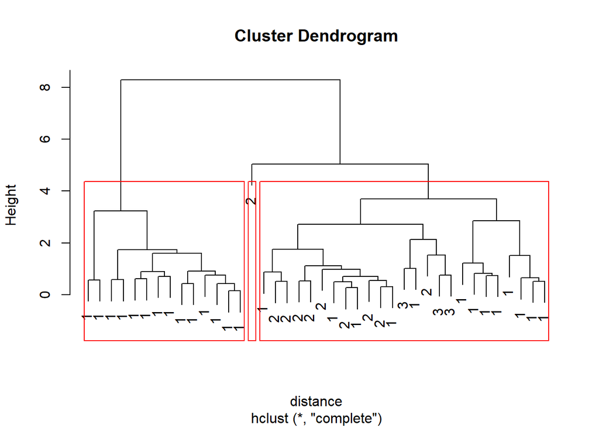

```r
plot(hc, labels = testData$origin)
#zakładamy 3 klastry, ponieważ są trzy wartości
groups <- cutree(hc, k=3)
#tworzenie borderów
rect.hclust(hc, k=3, border="red")
```

## Metoda K - średnich

Metoda k-średnich jest metodą należacą do grupy algorytmów analizy skupień tj. analizy polegającej na szukaniu i wyodrębnianiu grup obiektów podobnych (skupień).

Wykres służący z zapoznaniem się rozmieszczenia originu

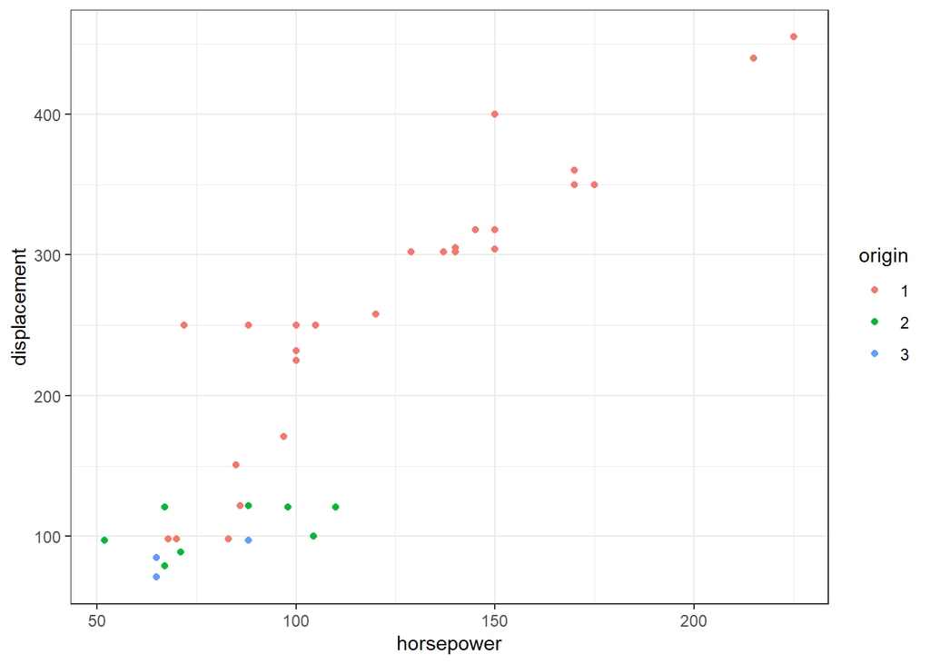

```r
ggplot(testData, aes(x= horsepower, y= displacement, color = origin)) + geom_point()
```

Wybranie odpowiednich kolumn i tworzenie klastrów

```r
testData<-testData %>% select(mpg,displacement, horsepower, weight, acceleration, model_year, origin)
#wiemy, że mają być 3 klastry
k.cluster <- kmeans(testData[,c(1:6)],3, nstart = 20)
#Wypisanie środków klastrów
print(k.cluster$centers)
```

```
##        mpg displacement horsepower   weight acceleration model_year
## 1 15.24118    326.41176  150.05882 4085.235     13.48235   73.82353
## 2 31.67857     95.92857   75.81924 2120.071     16.87143   77.07143
## 3 21.58889    186.11111   93.00000 3001.000     16.01111   75.11111
```

Przedstawienie klastrów

```r
table(testData$origin, k.cluster$cluster)
```

```
##
##      1  2  3
##   1 17  4  6
##   2  0  7  3
##   3  0  3  0
```

Wykres klastrów

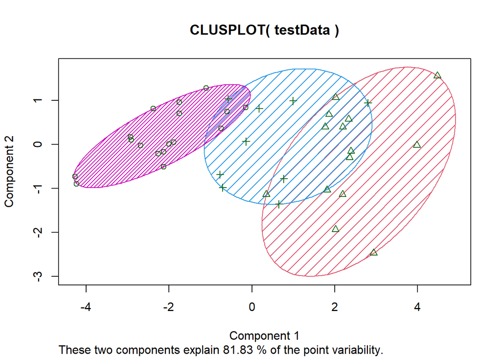

```r
library(cluster)
clusplot(testData, k.cluster$cluster, color=TRUE, shade=TRUE, labels=0,lines=0)
```

## Wykresy obrazujące analizę zbioru

Wyliczenie najpopularniejszych marek, obliczenie średniej i wyłuskanie wartości

```r
namesOccurence <- Autko %>% group_by(brand) %>% tally() %>% rename(Number_of_Occurences = n)
```

Wykres najpopularniejszych samochodów (top 20)

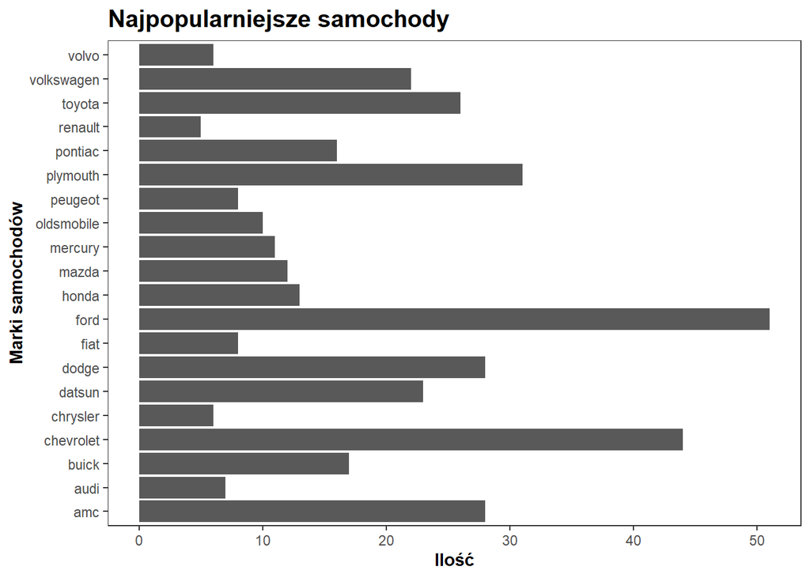

```r
namesOccurence  %>% top_n(20, Number_of_Occurences) %>% arrange(desc(Number_of_Occurences)) %>% ggplot(aes(x=brand, y=Number_of_Occurences)) +
  geom_bar(stat='identity') +
  coord_flip() +
  ggtitle("Najpopularniejsze samochody")+
  xlab("Marki samochodów")+
  ylab("Ilość") +
  theme_test() +
  theme(plot.title = element_text(size = 15,  face= 'bold', margin = ))+
  theme(legend.title =element_text(size = 40, face= 'bold'), legend.position = "bottom")+
  theme(axis.title.x = element_text( face="bold"))+
  theme(axis.title.y= element_text( face="bold"))
```

Najpopularniejszymi markami jest Ford i Chevrolet

Przedstawienie na wykresie kołowym

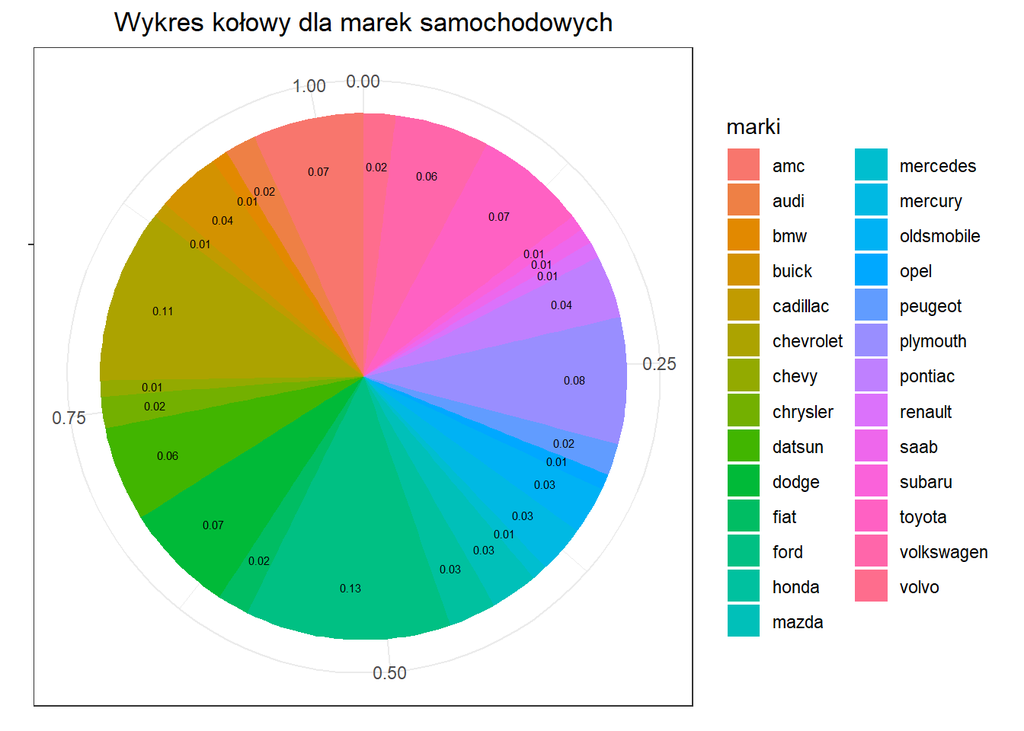

```r
#wyliczenie procentów
namesOccurence$procent <- round(namesOccurence$Number_of_Occurences / sum(namesOccurence$Number_of_Occurences), digits = 2)
pie <- namesOccurence %>% filter(procent>0) %>%
  ggplot(aes(x = "", y=procent ,fill = factor(brand))) +
  geom_bar(width = 1, stat = "identity") +
  theme(axis.line = element_blank(),
        plot.title = element_text(hjust=0.5)) +
  labs(fill="marki",
       x=NULL,
       y=NULL,
       title="Wykres kołowy dla marek samochodowych")

pie + coord_polar(theta = "y", start=0) +  geom_text(aes(x = 1.3, label = procent), position = position_stack(vjust = 0.5), size=2)
```

Wykres MPG dla każdej marki

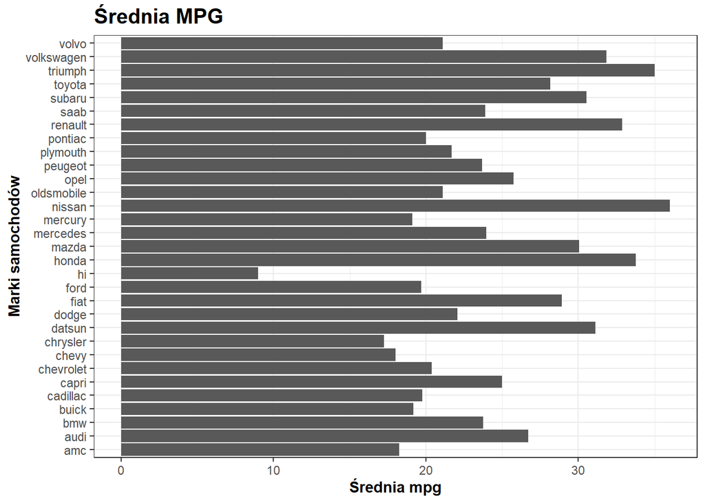

```r
Autko %>% group_by(brand) %>%
  summarise(sredniam = mean(mpg, na.rm = TRUE))  %>%
  ggplot(aes(x=brand, y=sredniam))+geom_bar(stat='identity')  + coord_flip()+
  xlab("Marki samochodów") +ylab("Średnia mpg")+
  ggtitle("Średnia MPG")+
  theme(plot.title = element_text(size = 15,  face= 'bold', margin = ))+
  theme(legend.title =element_text(size = 40, face= 'bold'), legend.position = "bottom")+
  theme(axis.title.x = element_text( face="bold"))+
  theme(axis.title.y= element_text( face="bold"))
```

Wykres ilości aut w danym roku

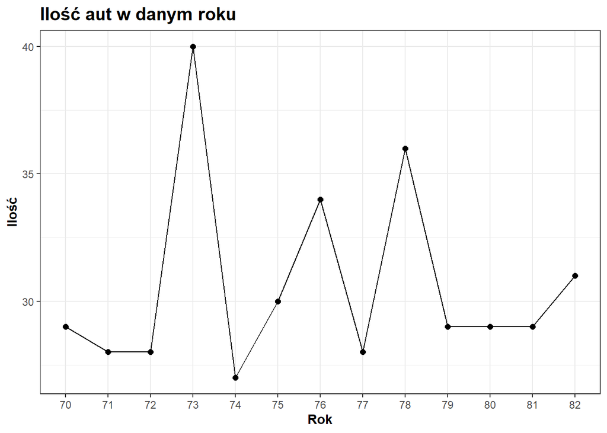

```r
Autko%>% group_by(model_year) %>%summarise(ilosc = n()) %>% ggplot(aes(x=model_year,y= ilosc ), lty=5)+
  geom_line(group=1)+
  geom_point(size=2)+
  theme_bw()+
  theme(legend.position = "none")+  xlab("Rok") +ylab("Ilość")+
  ggtitle("Ilość aut w danym roku")+
  geom_text(label="") +
  theme(axis.title.x = element_text( face="bold"))+
  theme(axis.title.y= element_text( face="bold")) +
  theme(plot.title = element_text(size = 15,  face= 'bold' ))
```

Wykres średnich horsepower i displacement w danym roku

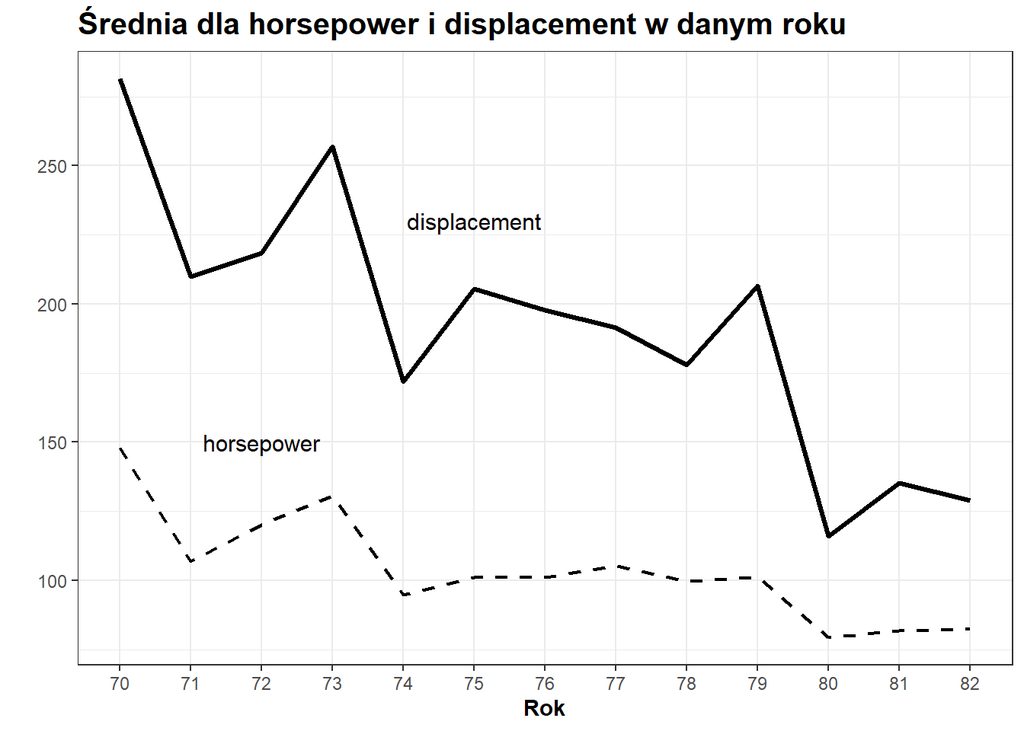

```r
Autko %>% group_by(model_year)%>% summarise(srednia = mean(horsepower), srednia2 = mean(displacement)) %>%
  ggplot(aes(x=model_year))+
  geom_line(aes(x = model_year, y=srednia, group = 1),lty=2, size=0.8)+
  geom_line(aes(x= model_year, y=srednia2, group = 1),size=1.2)+
  scale_color_gradient(low = 'blue', high = 'red')+
  theme_bw()+
  annotate(geom="text", x=6,y=230,
           label="displacement",color= "black", size=4 )+
  annotate(geom="text", x=3,y=150,
           label="horsepower",color= "black", size=4 ) +
  ggtitle("Średnia dla horsepower i displacement w danym roku")+
  theme(legend.position = "none")+
  labs(x="Rok",y="") +
  theme(axis.title.x = element_text( face="bold"))+
  theme(axis.title.y= element_text( face="bold")) +
  theme(plot.title = element_text(size = 15,  face= 'bold' ))
```

Z roku na rok można zauważyć spadek obu zmiennych

Wykres przedstawiający średnie mpg dla danych marek

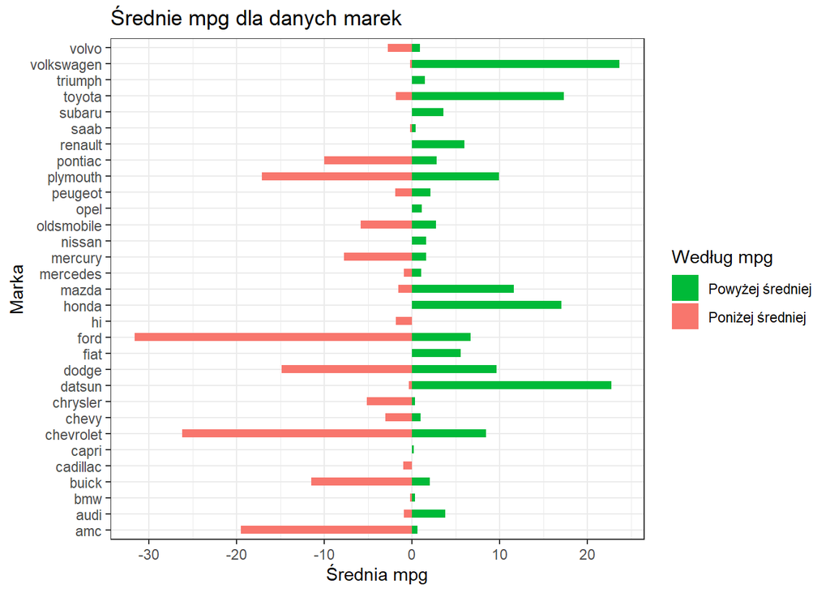

```r
#Dodanie nowej kolumny określającej mpg
Autko$mpgopt<- round((Autko$mpg - mean(Autko$mpg))/sd(Autko$mpg), 2)
Autko$typ <- ifelse(Autko$mpgopt < 0, "pod", "nad")
#Wykres
Autko %>%group_by(brand) %>% ggplot(aes(x=brand, y=mpgopt, label=mpgopt)) +
  geom_bar(stat='identity', aes(fill=typ), width=.5)  +
  scale_fill_manual(name="Według mpg",
                    labels = c("Powyżej średniej", "Poniżej średniej"),
                    values = c("nad"="#00ba38", "pod"="#f8766d")) +
  labs( title= "Średnie mpg dla danych marek") +
  coord_flip() +
  labs(x="Marka",y="Średnia mpg")
```